# Party/Date hub project

### Compute neighborhood for each type

```r
#computing neighbors and retrieving neighbor genes for BH
BH_neighbors <- neighborhood(eco_ppi_graph_lq,1, BH)
NBH_neighbors <- neighborhood(eco_ppi_graph_lq, 1, NBH)
BNH_neighbors <- neighborhood(eco_ppi_graph_lq, 1, BNH)
NBNH_neighbors <- neighborhood(eco_ppi_graph_lq, 1, NBNH)

#remove hubs from BH neighbors
for (i in 1:length(BH_neighbors)) {
  BH_neighbors[[i]] <- BH_neighbors[[i]][BH_neighbors[[i]]$name != BH[i]]
}

#remove hubs from NBH neighbors
for (i in 1:length(NBH_neighbors)) {
  NBH_neighbors[[i]] <- NBH_neighbors[[i]][NBH_neighbors[[i]]$name != NBH[i]]
}

#remove hubs from BNH neighbors
for (i in 1:length(BNH_neighbors)) {
  BNH_neighbors[[i]] <- BNH_neighbors[[i]][BNH_neighbors[[i]]$name != BNH[i]]
}

#remove hubs from NBNH neighbors
for (i in 1:length(NBNH_neighbors)) {
  NBNH_neighbors[[i]] <- NBNH_neighbors[[i]][NBNH_neighbors[[i]]$name != NBNH[i]]
}
```

#### Correlation in gene expression for BH

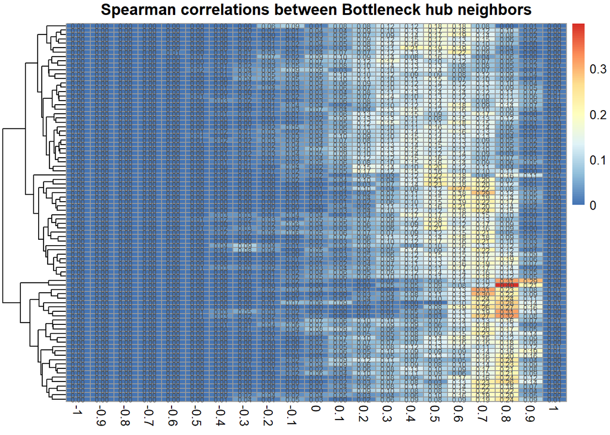

The dendogram define two main clusters ansd the upper part of the heatmap expresses a profile that is more line with date hubs.

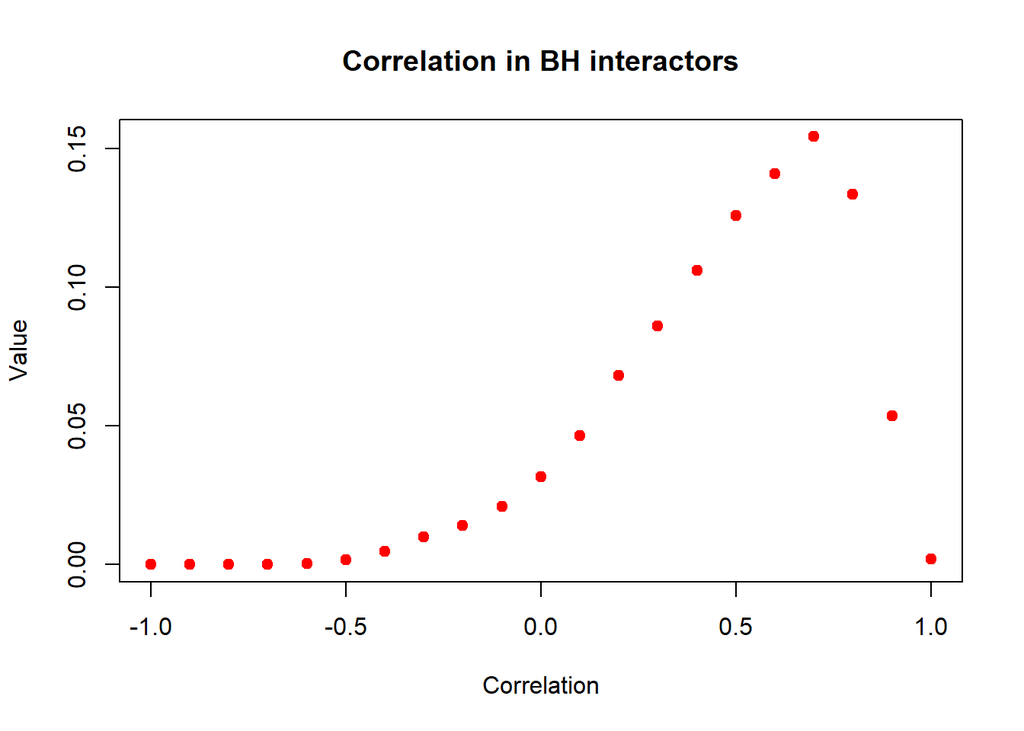

#### Correlation in gene expression for NBH

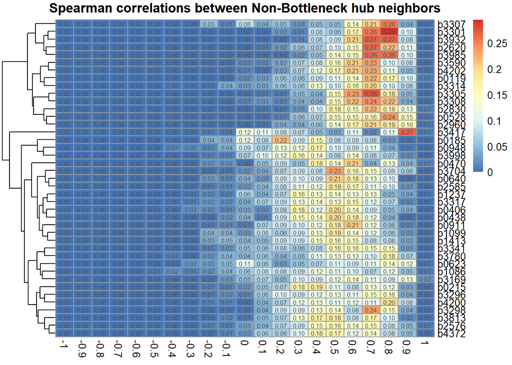

Heatmap for NBH is enriched in nodes expressing a date-like pattern in the lower part. In the upper part there are several interaction falling within more than 1 bin of correlation for the same protein. This can be a clue for interaction complexes.

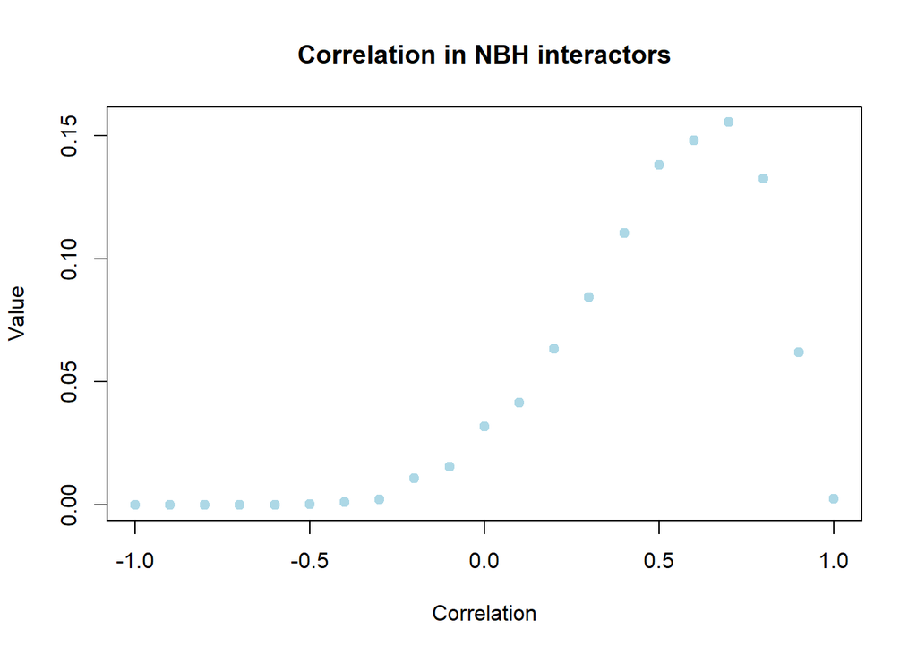

Not any remarkable difference with BH.

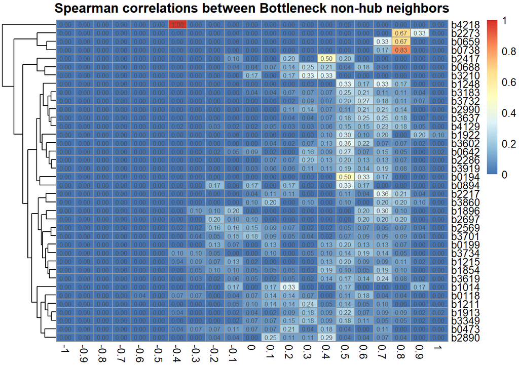

#### Correlation in gene expression for NBNH

```r
mask <- array()
for (i in 1:length(NBNH_neighbors)) {
  mask[i] <- length(NBNH_neighbors[[i]]) != 1
}
NBNH_neighbors <- NBNH_neighbors[mask]
```

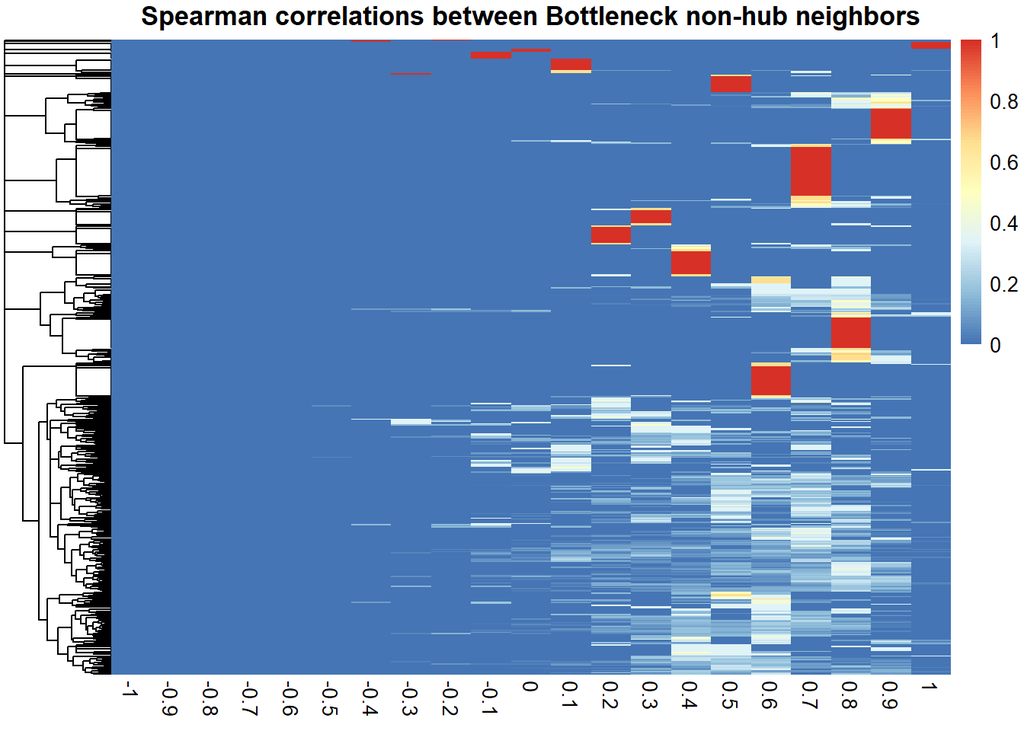

#### Correlation for identification

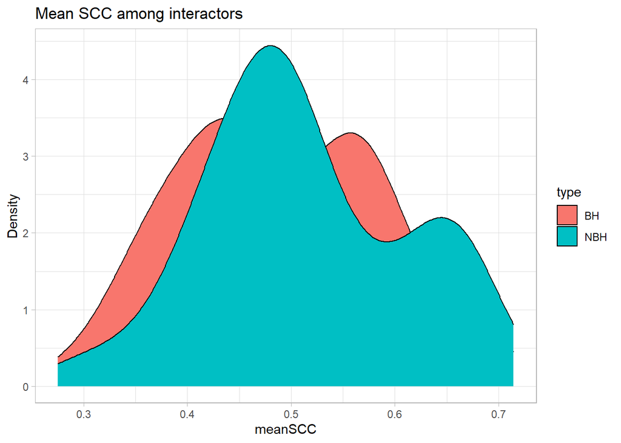

Bimodality appears to be recovered, especially for BH. Let’s look at BH in particular. NBH distribution shape is not as expected. Beeing NBH linked most with party hubs, the peak on the right should be more consistent but this is not the case. Anyway, the left BH peak (around 0.45) respect the expectations as bottleneck hubs should be linked with date hubs.

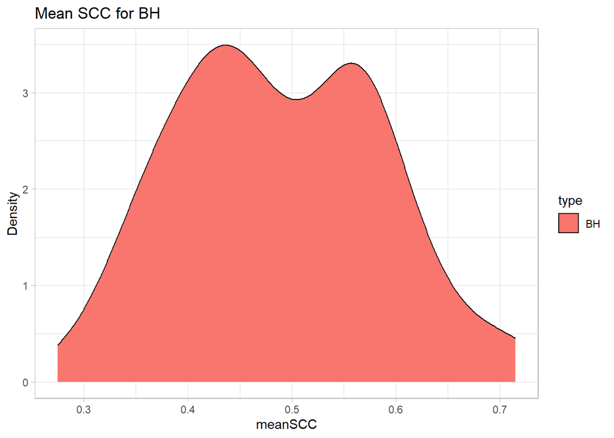

In BH, bimodality is more recovered ,with the left bell-shaped curve beeing slightly higher in density. The two peaks are divided by a treshold around 0.5 Variance:

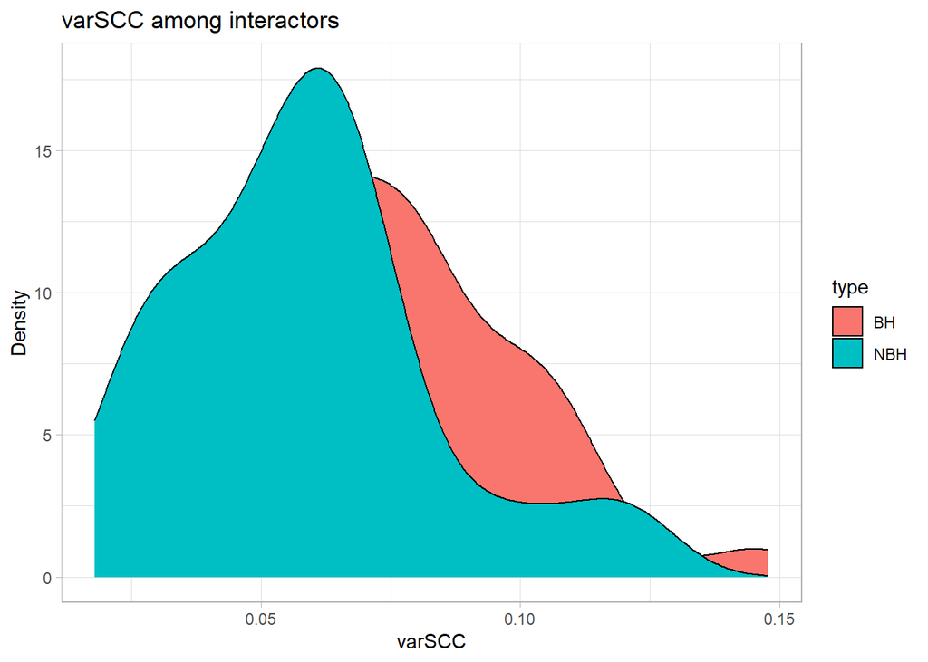

As expected, also in this case, data is much more noisy than before for both BH and NBH.

Validation of bimodality in hubs:

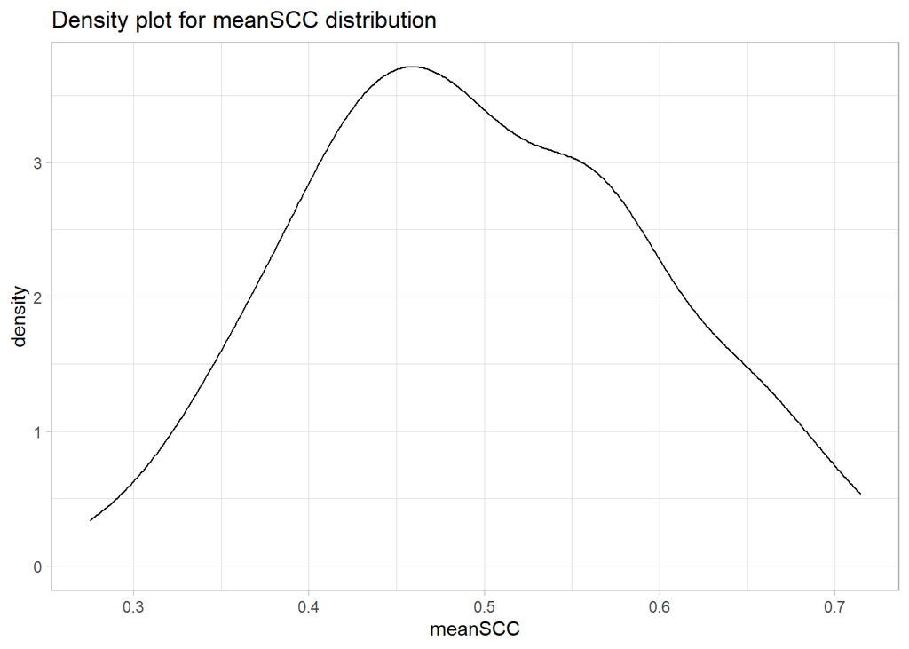

This distribution has a weak bimodal pattern due to NBH. It’s then difficult to assess a treshold for classification considering all hubs. For this reason, we try to make this classification considering BH and NBH separately.

#### Dimensionality reductions

```r
#the two peaks in NBH meanSCC distribution are divided at 0.5.
meanSCC_treshold_BH <- 0.5
#the two peaks in NBH meanSCC distribution are divided at 0.6.
meanSCC_treshold_NBH <- 0.6

metrics_BH <- metrics_lq[metrics_lq$type == "BH", ]
metrics_NBH <- metrics_lq[metrics_lq$type == "NBH", ]
classification_BH <- rep('Party', length(metrics_BH$meanSCC))
classification_NBH <- rep('Party', length(metrics_NBH$meanSCC))
classification_BH[metrics_BH$meanSCC <= meanSCC_treshold_BH] <- 'Date'
classification_NBH[metrics_NBH$meanSCC <= meanSCC_treshold_NBH] <- 'Date'
#assigning the classification of party/date hub to the stats dataframe containing all infos for hubs.
stats_lq[seq(1,length(BH)), 'classification'] <- classification_BH
stats_lq[seq(1,length(NBH)), 'classification'] <- classification_NBH
```

We can plot the counts of party and date hubs using obtained using the treshold he distribution of meanSCC with the selected treshold

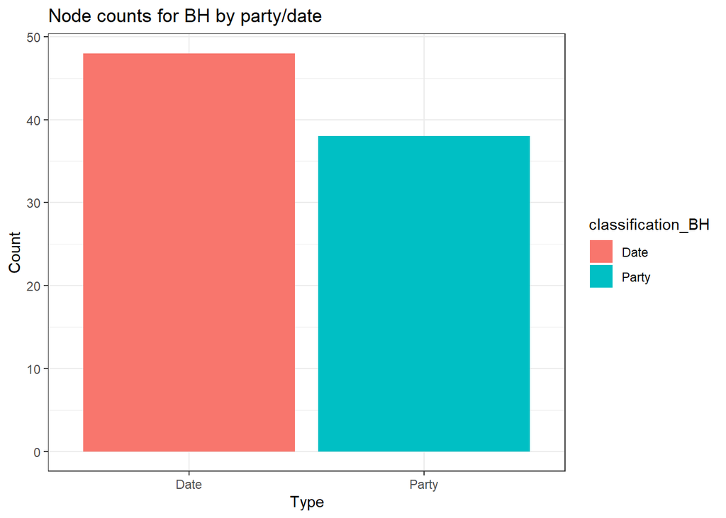

```r
ggplot(stats_lq[!is.na(stats_lq$classification_BH),]) +
  geom_histogram(aes(x=classification_BH, fill=classification_BH), stat = "count") +
  ggtitle("Node counts for BH by party/date") +
  ylab("Count") +
  xlab("Type") +
  theme_bw()
```

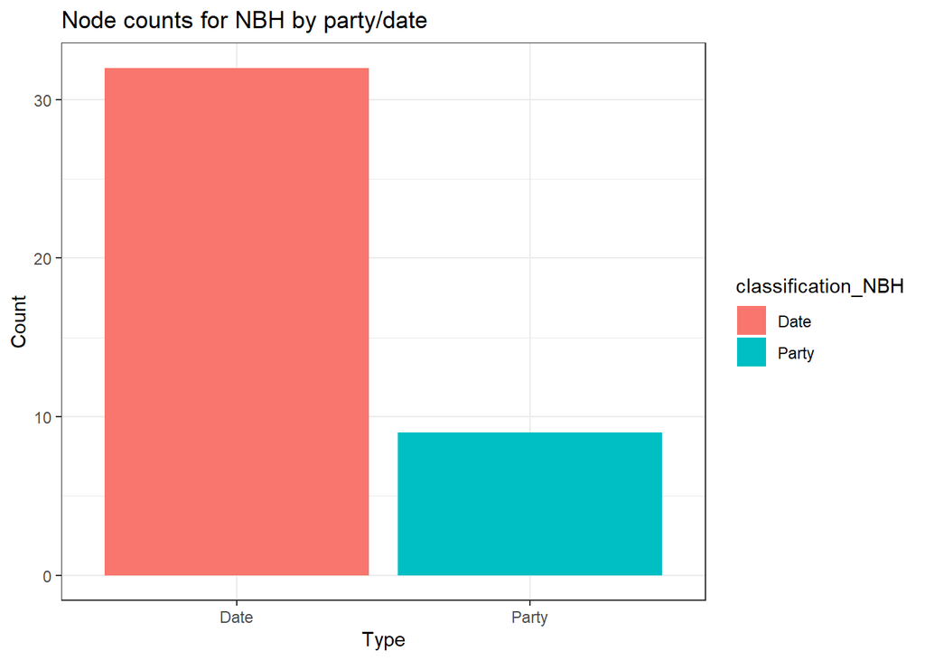

```r
ggplot(stats_lq[!is.na(stats_lq$classification_NBH),]) +
  geom_histogram(aes(x=classification_NBH, fill=classification_NBH), stat = "count") +
  ggtitle("Node counts for NBH by party/date") +
  ylab("Count") +
  xlab("Type") +
  theme_bw()
```

Both BH and NBH are enriched in date hubs, which is expected for BH but not NBH (where the enrichment in date hubs is higher). We now apply PCA dimensionality reduction

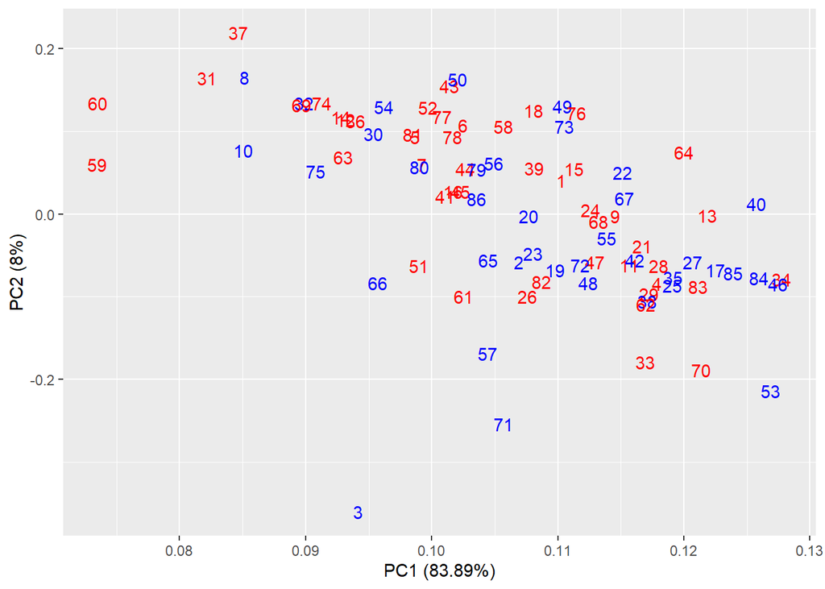

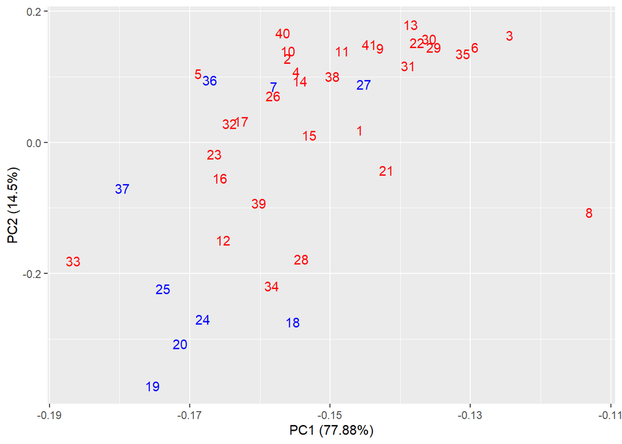

In BH, nodes do not clusterize according to their type, neither along the first nor the second PCs. For what regard NBH, nodes clusterize according to color. The first two components explain almost all the variance for both BH and NBH (around 90%). We use elbow plot to choose PCs for UMAP to try whether this technique may produce clusters based on date/party membership.

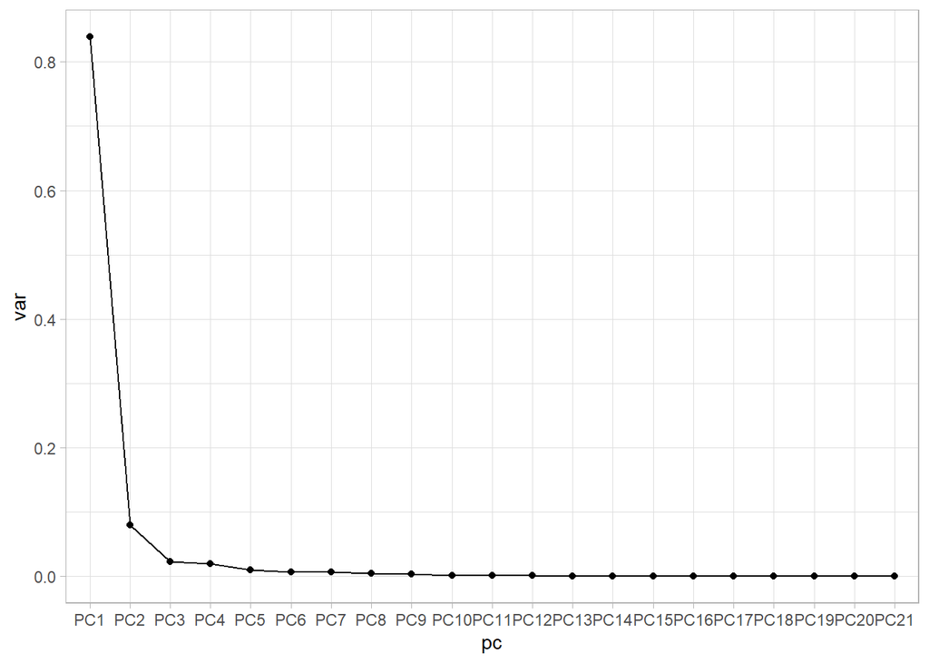

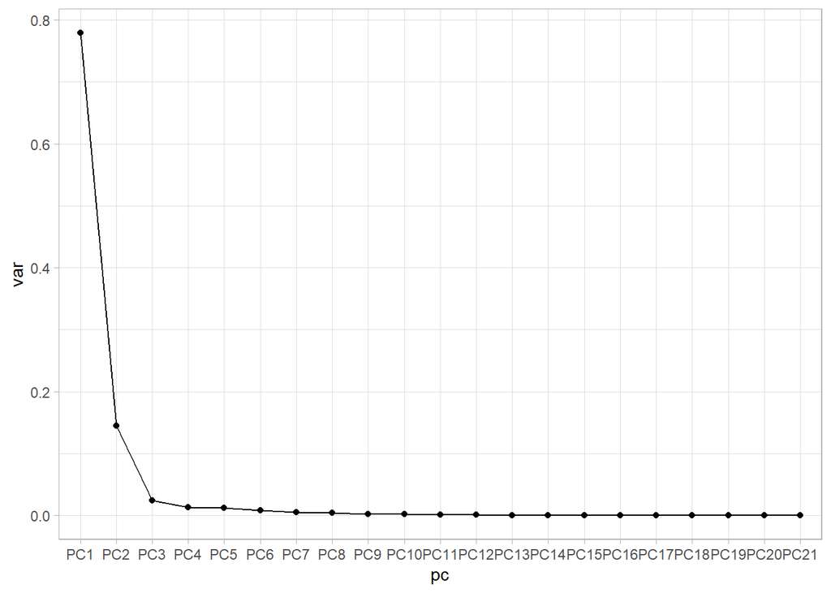

We can see that both variances can be explained quite-well by 3 components. 6 components can suit for the umap.

```r
U<-umap(t(BH_counts), pca=6, n_components = 3)
plot3d(x=U[,1],y=U[,2],z=U[,3], col=color_BH)
rglwidget()
```

[interactive chart not shown]

```r
U<-umap(t(NBH_counts), pca=6, n_components = 3)
plot3d(x=U[,1],y=U[,2],z=U[,3], col=color_NBH)
rglwidget()
```

[interactive chart not shown]

```r
party_hubs_BH <- as.list(filter(metrics_BH, metrics_BH$meanSCC > meanSCC_treshold_BH))[1]
date_hubs_BH <- as.list(filter(metrics_BH, metrics_BH$meanSCC <= meanSCC_treshold_BH))[1]

party_hubs_NBH <- as.list(filter(metrics_NBH, metrics_NBH$meanSCC > meanSCC_treshold_NBH))[1]
date_hubs_NBH <- as.list(filter(metrics_NBH, metrics_NBH$meanSCC <= meanSCC_treshold_NBH))[1]
```

## Conclusions

In This analysis, we have tried to classify date and party hubs using correlation in expression values among all the interactors for a given hub, not considering the hub itself. After having categorized nodes according to their degree (hubs vs non-hubs) and for their betwenness value (bottleneck hubs vs non-bottleneck hubs), we have carried three different analyses based on a parameter representing how reliable interactions are. Best classificaition and results were given by considering only high-confidence interactions, meaning that not only information loss (given by exclusion of low-confidence PPI) does not compromise the goodness of the results, but it does improve them.

## Classification of Party/Date hubs using Semantic Similarity measures

```r
library(GOSemSim)
```

### Information content-based method

The method proposed by Resnik are information content (IC) based, which depends on the frequencies of two GO terms involved and that of their closest common ancestors term in a specific corpus of GO annotations. The information content of a GO term is computed by the negative log probability of the term occurring in GO corpus. A rarely used term contains a greater amount of information. The frequency of a term *t* is defined as:

$$p(t) = \frac{n_{t}}N|t^i \in \{t,childrenoft\}$$
where *nt’* is the number of term t’, and *N* is the total number of GO corpus.

Thus the information content is defined as.

$$IC(t) = -log(p(t))$$
As GO allow multiple parents for each concept, two terms can share parents by multiple paths. IC-based methods calculate similarity of two GO terms based on the information content of their closest common ancestor term, which is also called Most Informative Common Ancestor (MICA).

### Resnik’s method

The Resnik’s method is defined as:

$$sim_{Resnik}(t_1,t_2) = IC(MICA)$$

Since a gene product can be annotated my multiple GO terms, semantic similarity among gene products need to be aggregated from different semantic similarity scores of multiple GO terms associated with genes, including **max**, **avg**, **rcmax** and **BMA**. For this project, we will use average semantic similarity score:

$$sim_{avg}(g1,g2) = \frac{\sum_{i = 1}^{m} \sum_{j = 1}^{n}
sim(go_{1i},go_{2j})}{\ m * n}$$

### Summary

The idea behind semantic similarity measurement is the notion than genes (or gene products) with similar function should have similar annotation vocabulary and have a close relationship in the ontology structure. Similar object tend to behave similarly, which supports many applications to infer gene (gene products) functions but also, as in our case, protein-protein interactions

```r
Eck12_GO <- godata('org.EcK12.eg.db', ont="BP", keytype = "SYMBOL")
```

```
## preparing gene to GO mapping data...
```

```
## preparing IC data...
```

In order to use this package, ENTREZ identifiers for each protein are necessary. They can be retrieved using **pathview** package, converting gene symbols to ENTREZ identifier. In order to be coherent with the best results yielded in previous analyses, we will use Resnik’s method only on hubs composed by high-quality PPI.

As in [1] a hub protein is labeled as party hub if it shares at least one functional module with its neighbors with a higher percentage above the treshold (they used a treshold of 0.5). Date party in the other way aroud. In this perspective i create a function to retrieve the name for each interactor for each hub.

```r
id_to_name <- function (neighbor) {
  names <- A[match(neighbor$name, A$`Protein ID`),1]
  neighbor <- vector()
  neighbor <- names
  return(neighbor)
}

hubs_neighbors_name <- lapply(hubs_neighbors_hq, id_to_name)
```

Now i create a function that takes as input the neighborhood for hubs and compute the average semantic similarity measures for each group of interaction have to apply `mgeneSim` function, which calculates semantic similarity measure for a group of interactors for a given hub. We thus labeled a hub protein a party hub if it shares at least one functional module with its neighbors with a higher percentage of the threshold (for our experiments we used a threshold of 0.5). In other words, it is a party hub if the neighbors of a higher percentage of the threshold belong to the same functional modules to the hub protein. On the other hand, a hub protein is labeled as a date hub if the percentage for each functional module it shares with its neighbors does not exceed the threshold (the same threshold for both party and date hubs).

```r
find_party_hubs <- function (neighborhood, treshold) {
  matrix <- mgeneSim(neighborhood, semData=Eck12_GO, measure="Resnik", combine="avg", verbose=FALSE)
  party_hubs_semsim <- names(mean(rowSums(matrix)[1]) > treshold)
  return(party_hubs_semsim)
}

find_date_hubs <- function (neighborhood, treshold) {
  matrix <- mgeneSim(neighborhood, semData=Eck12_GO, measure="Resnik", combine="avg", verbose=FALSE)
  date_hubs_semsim = vector()
  date_hubs_semsim <- c(date_hubs_semsim, names(mean(rowSums(matrix)[1]) <= treshold))
  return(date_hubs_semsim)
}
```

```r
party_h_semsim <- lapply(hubs_neighbors_name, find_party_hubs, 0.5)
date_h_semsim <- lapply(hubs_neighbors_name, find_date_hubs, 0.5)
```

Unfortunately, i get a dimension problem that, as now, i’m not able to fix. Anyway, the purpose of this analysis is to calculate the average semantic similarity between each hub and its interactors. Then, this result has to be compared with the treshold to define date and partu hubs. Once done this, my purpose was to compare results obtained with the analysis using HQ-PPI interactions with the ones obtained by this analysis. Anyway, in order to give a sense at least to the first analysis, i will carry out biological validation identifying the hub with the highest value in correlation with its neighbors and check in literature whether it can be effectively considered as date or party hub.

## Biologically validate HQ-PPI Analysis

```r
#Create a function that returns all the names of each node identified by protein ID
get_names <- function(nodes){
  return(A[match(nodes, A$`Protein ID`),1])
}

metrics_hq["name"] <- get_names(metrics_hq$hubs)
metrics_hq <- metrics_hq %>% relocate(name)
#plot the top scoring genes for expression in correlation values, which should represent party hubs
metrics_hq %>% arrange(desc(meanSCC)) %>% head()
```

```
##       name  hubs type   meanSCC      varSCC
## b3649 rpoZ b3649  NBH 0.8307720 0.012701421
## b4101 phnG b4101  NBH 0.8045113 0.006777093
## b0470 dnaX b0470  NBH 0.8011326 0.009650602
## b3303 rpsE b3303  NBH 0.7977106 0.004884506
## b1094 acpP b1094   BH 0.7911540 0.007902518
## b4052 dnaB b4052   BH 0.7664952 0.006658563
```

```r
#get the neighborhood from the name of the hub most correlated in expression with its neighbhors
get_hub_neighs <- function(hub){
  neigh <- hubs_neighbors_hq[[match(hub, hubs_hq)]]$name
  return(get_names(neigh))
}

metrics_hq <- metrics_hq %>% arrange(desc(meanSCC))
get_hub_neighs(metrics_hq$hubs[1])
```

```
## [1] "rpoZ" "rpoD" "rpoA" "rpoB" "rpoC"
```

rpoZ is one of the hubs present in `party_hubs_hq`, showing consistency in results.

Rpoz, rpoD, rpoA, rpoB and related protein encodes for subunits of the bacterial polymerase and homologous plastid-encoded RNA polymerase (https://biocyc.org/gene?orgid=ECOLI&id=EG10894). Encoding for polymerase means that they are constitutively expressed and for this reason rpoZ can then be classified as party hub. Let’s look at date party, which we assume at the bottom in the ranking for correlation:

[output not shown]

## References

1. Edward Casey Kenley, Lyles Kirk, and Young-Rae Cho. 2011. Differentiating party and date hubs in protein interaction networks using semantic similarity measures. In Proceedings of the 2nd ACM Conference on Bioinformatics, Computational Biology and Biomedicine (BCB ’11). Association for Computing Machinery, New York, NY, USA, 641–645. https://doi.org/10.1145/2147805.2147916
2. Revisiting Date and Party Hubs: Novel Approaches to Role Assignment in Protein Interaction Networks Agarwal S, Deane CM, Porter MA, Jones NS (2010) Revisiting Date and Party Hubs: Novel Approaches to Role Assignment in Protein Interaction Networks. PLOS Computational Biology 6(6): e1000817. https://doi.org/10.1371/journal.pcbi.1000817
3. Ning, Kang, Hoong Kee Ng, Sriganesh Srihari, Hon Wai Leong, and Alexey I. Nesvizhskii. 2010. “Examination of the Relationship Between Essential Genes in PPI Network and Hub Proteins in Reverse Nearest Neighbor Topology.” BMC Bioinformatics 11 (1): 505. https://doi.org/10.1186/1471-2105-11-505.
4. Yu, Haiyuan, Philip M Kim, Emmett Sprecher, Valery Trifonov, and Mark Gerstein. 2007. “The Importance of Bottlenecks in Protein Networks: Correlation with Gene Essentiality and Expression Dynamics.” Edited by Diana Murray. PLoS Computational Biology 3 (4): e59. https://doi.org/10.1371/journal.pcbi.0030059.
5. The Importance of Bottlenecks in Protein Networks: Correlation with Gene Essentiality and Expression Dynamics Yu H, Kim PM, Sprecher E, Trifonov V, Gerstein M (2007) The Importance of Bottlenecks in Protein Networks: Correlation with Gene Essentiality and Expression Dynamics. PLOS Computational Biology 3(4): e59. https://doi.org/10.1371/journal.pcbi.0030059